# Math COVID EDA 2

Emi

2023-03-11

```r
library(dplyr)
library(tidyverse)
```

# Loading Datasets

```r
mathCOVID <- readxl::read_excel('../data/KidsCOVID_Winter21_raw data.xlsx')
```

# Cleaning Data

```r
# Omitting rows with NA values from data
df_nd <- mathCOVID %>%
          mutate(drop = replace_na(drop, 0)) %>%
          filter(drop != 1) %>%
          mutate("id"= row_number(), .before = drop )
head(df_nd)
```

```
## # A tibble: 6 × 410
##      id  drop dropwhy incomplete_pt1 incomplete_pt2 `did not do_pt2`
##   <int> <dbl> <chr>            <dbl>          <dbl>            <dbl>
## 1     1     0 <NA>                NA              1               NA
## 2     2     0 <NA>                NA             NA               NA
## 3     3     0 <NA>                NA             NA               NA
## 4     4     0 <NA>                NA             NA               NA
## 5     5     0 <NA>                NA             NA               NA
## 6     6     0 <NA>                NA             NA               NA
## # … with 404 more variables: `Scratch paper_pt1` <dbl>,
## #   `Scratch paper_pt2` <dbl>, `Subject ID #...8` <chr>,
## #   `Subject ID #...9` <chr>, Notes <chr>, StartDate...11 <dttm>,
## #   EndDate...12 <dttm>, Progress...13 <dbl>, Condition <chr>,
## #   `UPDATED_Opt-in-out` <dbl>, Opt_Out <chr>,
## #   `Duration (in seconds)...17` <dbl>, Finished...18 <dbl>,
## #   RecordedDate...19 <dttm>, Browser_info_Browser...20 <chr>, …
```

```r
df <- df_nd %>%
    select("id", "Condition", "Sex", "Base_Enjoy", "Base_Worry",
            "During_OverallAcc", "During_HOT", "DurImm_OverallAcc", "DurImm_HOT",
            "Del_OverallAcc", "Del_acc", "Del_HOT",
           "Understand_avg", "PaidAttn_avg",
           "SI_1","SI_2","SI_3","SI_4","SI_5","SI_6","SI_7","SI_8","SI_9","SI_10",
           "SI_avg")
head(df)
```

```
## # A tibble: 6 × 25
##      id Condition   Sex Base_Enjoy Base_Worry During_OverallAcc During_HOT
##   <int> <chr>     <dbl>      <dbl>      <dbl>             <dbl>      <dbl>
## 1     1 2            NA          0          2             0.167       0.25
## 2     2 1             1          3          1             0.5         0.75
## 3     3 1             1          4          3             0.833       1
## 4     4 1             1          3          1             0           0
## 5     5 1             2          4          1             0.833       1
## 6     6 2            NA          4          1             0.667       1
## # … with 18 more variables: DurImm_OverallAcc <dbl>, DurImm_HOT <dbl>,
## #   Del_OverallAcc <dbl>, Del_acc <dbl>, Del_HOT <dbl>, Understand_avg <dbl>,
## #   PaidAttn_avg <dbl>, SI_1 <dbl>, SI_2 <dbl>, SI_3 <dbl>, SI_4 <dbl>,
## #   SI_5 <dbl>, SI_6 <dbl>, SI_7 <dbl>, SI_8 <dbl>, SI_9 <dbl>, SI_10 <dbl>,
## #   SI_avg <dbl>
```

```r
# Emotion dataset: Enjoy/Worry with Mind Wandering and Understanding Factors
emotion_df <- df_nd %>% select("id","Condition", "Sex", contains("Enjoy"), contains("Worry")) %>% mutate(pre  = Base_Enjoy - Base_Worry,
              emotion0 = Enjoy_0 - Worry_0,
              emotion1 = Enjoy_1 - Worry_1,
              emotion2 = Enjoy_2 - Worry_2,
              emotion3 = Enjoy_3 - Worry_3,
              emotion4d = D_Enjoy_1 - D_Worry_1,
              emotion5d = D_Enjoy_2 - D_Worry_2,
              emotion6d = D_Enjoy_3 - D_Worry_3,
              emotion_dur_avg = Enjoy_During_avg - Worry_During_avg,
              emotion_imm_avg = Enjoy_Imm_avg - Worry_Imm_avg,
              emotion_durI_avg = Enjoy_DurImm_avg - Worry_DurImm_avg,
              emotion_del_avg = Enjoy_Del_avg - Worry_Del_avg)
mw_under <- df_nd %>% select("MW_day1_avg", "MW_day2_avg", contains("under"))
emotion_df = cbind(emotion_df, mw_under)
head(emotion_df)
```

```
##   id Condition Sex Base_Enjoy Enjoy_0 Enjoy_1 Enjoy_2 Enjoy_3 Enjoy_4 D_Enjoy_1
## 1  1         2  NA          0       1       2       2       1       2         2
## 2  2         1   1          3       4       3       3       4       4         4
## 3  3         1   1          4       4       3       2       3       3         1
## 4  4         1   1          3       3       2       1       0       0         2
## 5  5         1   2          4       4       3       3       3       3         4
## 6  6         2  NA          4       3       3       3       3       3        NA
##   D_Enjoy_2 D_Enjoy_3 Enjoy_During_avg Enjoy_Imm_avg Enjoy_DurImm_avg
## 1        NA        NA              1.2             2         1.333333
## 2         4         4              3.4             4         3.500000
## 3         1         2              3.2             3         3.166667
## 4         1         1              1.8             0         1.500000
## 5         3         4              3.4             3         3.333333
## 6        NA        NA              3.2             3         3.166667
##   Enjoy_Del_avg Base_Worry Worry_0 Worry_1 Worry_2 Worry_3 Worry_4 D_Worry_1
```

[output cut: 34 more lines]

# Observe Causal Effect of Worked Example vs No Worked Example

Let $U_i$ denote understanding level of i-th student, $M_i$ denote mind wandering level of i-th student, $z$ denotes the condition ($z = 1$ represents worked example group, and $z = 0$ represents no worked example)

- On student’s understanding level: $U\Delta_i = U_i(z = 1) - U_i(z = 0)$
- On student’s mind wandering level: $M\Delta_i = M_i(z = 1) - M_i(z = 0)$

```r
# Create a table with: id, condition z, Y(1), Y(0), and causal effect Y(1) - Y(0)
mw_under_avg_cond <- emotion_df %>% select("id","Condition", "Sex", contains("MW"), contains("under")) %>%
  #filter(Condition == 1) #%>%
  group_by(Condition) %>% summarize(mw = mean(MW_day1_avg, na.rm = TRUE),
                                    understanding = mean(Understand_avg, na.rm = TRUE)) %>% mutate(Condition = c("Worked EX","No Worked EX"))
mw_under_avg_cond
```

```
## # A tibble: 2 × 3
##   Condition       mw understanding
##   <chr>        <dbl>         <dbl>
## 1 Worked EX     2.17          79.6
## 2 No Worked EX  2.29          74.2
```

```r
df_t <- data.frame(t(mw_under_avg_cond)) %>% slice(2:3)
SPF <- df_t %>% mutate(SPF = as.numeric(X1) - as.numeric(X2)) %>% select("SPF")
SPF
```

```
##                     SPF
## mw            -0.114881
## understanding  5.396780
```

**Mind Wandering Effect:** The no worked example group had higher average mind wandering score than the worked example group (but by very very small)

**Understanding:** The worked example group had higher understanding level than the no worked example group (possible to make a causation between worked example and understanding level)

## More Data Visualization

### Variables of Interest

- Y: Mind wandering score (tracked each day) and understanding level (one data)
- X: Enjoy (how much student was enjoying the activity), Worry (how much student was feeling worried towards the activity), Emotion (overall emotion score)

`Enjoy_During_avg` / `Worry_During_avg`: Students were asked during the lessons to record their emotion

`Enjoy_DurImm_avg` / `Worry_DurImm_avg`: Students were asked immediately after the lessons to record their emotion

`Enjoy_Del_avg` / `Worry_Del_avg`: Students were asked after the study to record their emotion

(In each period, their mind wandering score and understanding level were also recorded)

**How Does Students’ Emotions Affect Their Understanding and Mind Wandering**

```r
acc <- df_nd %>% select(During_OverallAcc,DurImm_OverallAcc, Del_OverallAcc)
emotion_df2 <- emotion_df %>% select(id, Condition,Sex,Base_Enjoy,Base_Worry, contains("avg")) %>%
          select(-c(Worry_Imm_avg, Enjoy_Imm_avg, emotion_imm_avg))
emotion_df2 <- cbind(emotion_df2, acc)
```

```r
enjoy <- emotion_df2 %>% select(1:4, 6:8, 15:20) %>% mutate(emotion = "Enjoy")
worry <- emotion_df2 %>% select(1:3, Base_Worry, 9:11, 15:20) %>% mutate(emotion = "Worry")
col_names <- c("id","cond", "sex", "pre","dur", "durI","del","mw1","mw2","under","dur_acc", "durI_acc", "del_acc","emotion" )
colnames(enjoy) <- col_names
colnames(worry) <- col_names
worry2 <- worry %>% mutate(pre = -pre, dur = -dur, durI = -durI, del = -del)
```

### During Study Data

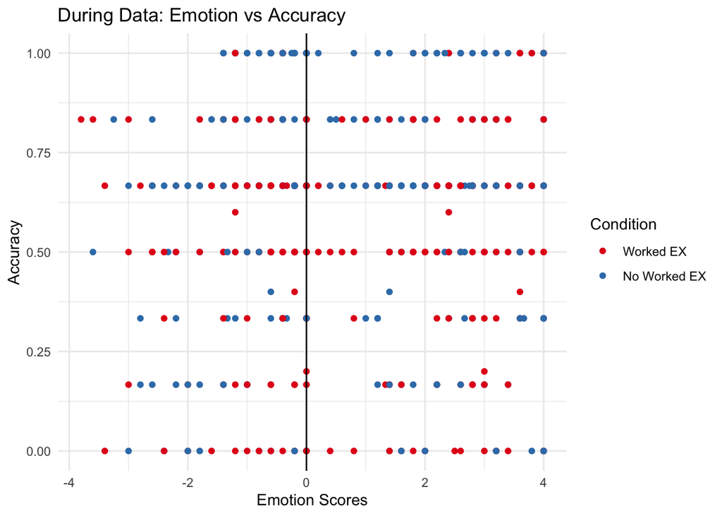

```r
rbind(enjoy, worry2) %>%
  ggplot(aes(x = dur, y = dur_acc, color = cond)) + geom_point() +
  geom_vline(xintercept = 0) + theme_minimal() +
  labs(title = "During Data: Emotion vs Accuracy", x = "Emotion Scores", y = "Accuracy", color = "Condition") +
  scale_color_brewer(palette="Set1", labels = c("Worked EX", "No Worked EX"))
```

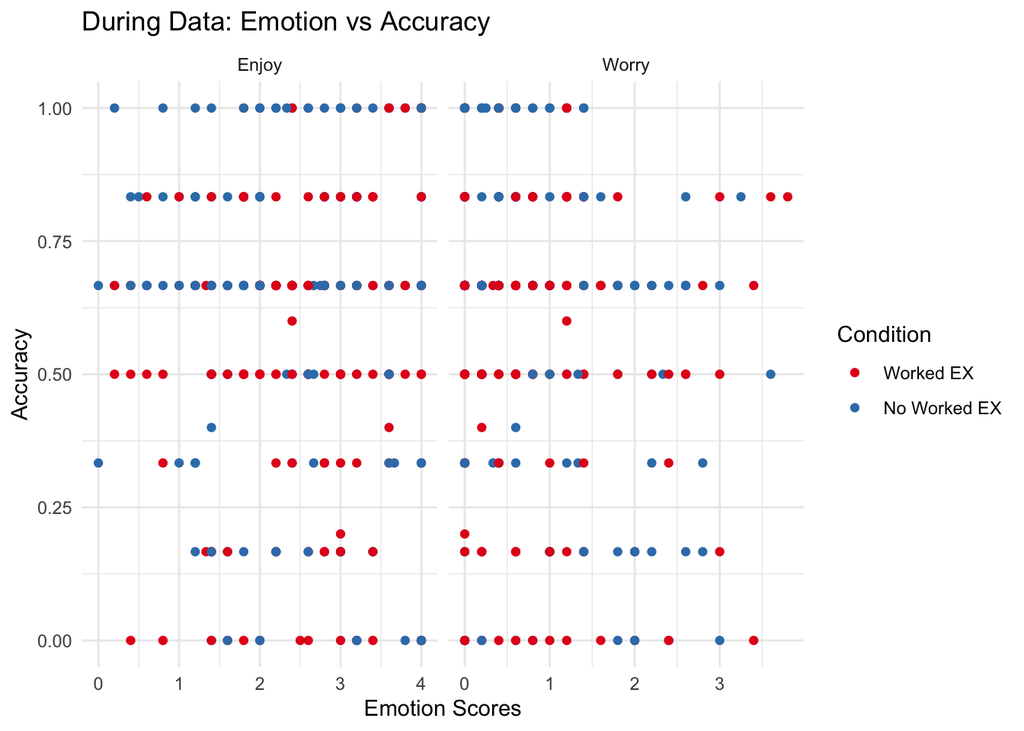

```r
rbind(worry, enjoy) %>%
  ggplot(aes(x = dur, y = dur_acc, color = cond)) + geom_point() +
  facet_grid(.~emotion, scales = "free", labeller = labeller(enjoy = "Enjoy", worry = "Worry")) +
  theme_minimal() +
  labs(title = "During Data: Emotion vs Accuracy", x = "Emotion Scores", y = "Accuracy", color = "Condition") +
  scale_color_brewer(palette="Set1", labels = c("Worked EX", "No Worked EX"))
```

### During Immediate Data

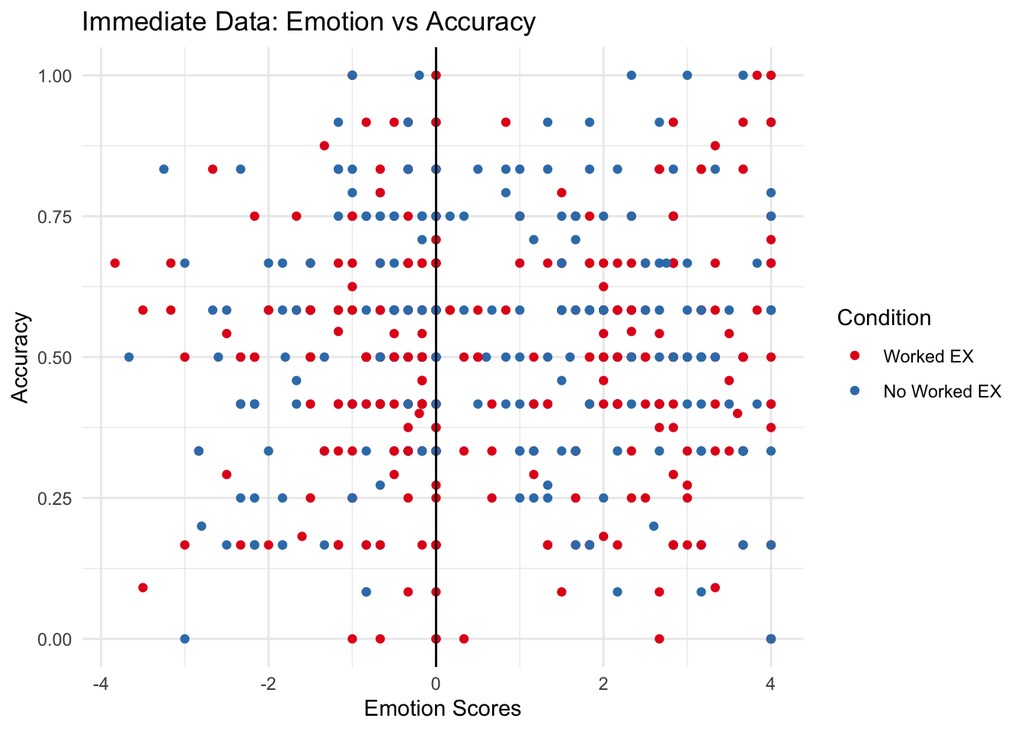

```r
rbind(enjoy, worry2) %>%
  ggplot(aes(x = durI, y = durI_acc, color = cond)) + geom_point() +
  geom_vline(xintercept = 0) + theme_minimal() +
  labs(title = "Immediate Data: Emotion vs Accuracy", x = "Emotion Scores", y = "Accuracy", color = "Condition") +
  scale_color_brewer(palette="Set1", labels = c("Worked EX", "No Worked EX"))
```

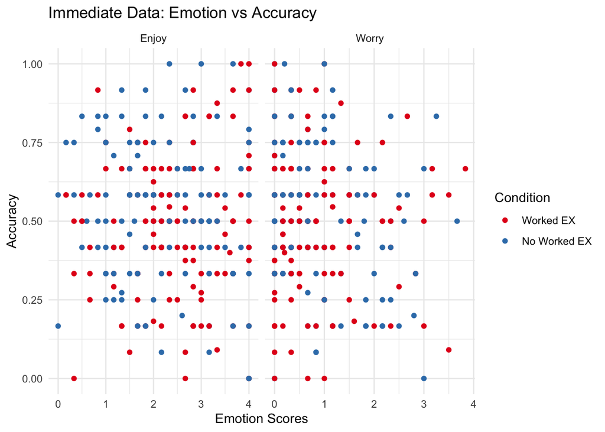

```r
rbind(worry, enjoy) %>%
  ggplot(aes(x = durI, y = durI_acc, color = cond)) + geom_point() +
  facet_grid(.~emotion, scales = "free", labeller = labeller(enjoy = "Enjoy", worry = "Worry")) +
  theme_minimal() +
  labs(title = "Immediate Data: Emotion vs Accuracy", x = "Emotion Scores", y = "Accuracy", color = "Condition") +
  scale_color_brewer(palette="Set1", labels = c("Worked EX", "No Worked EX"))
```

### Delayed Data

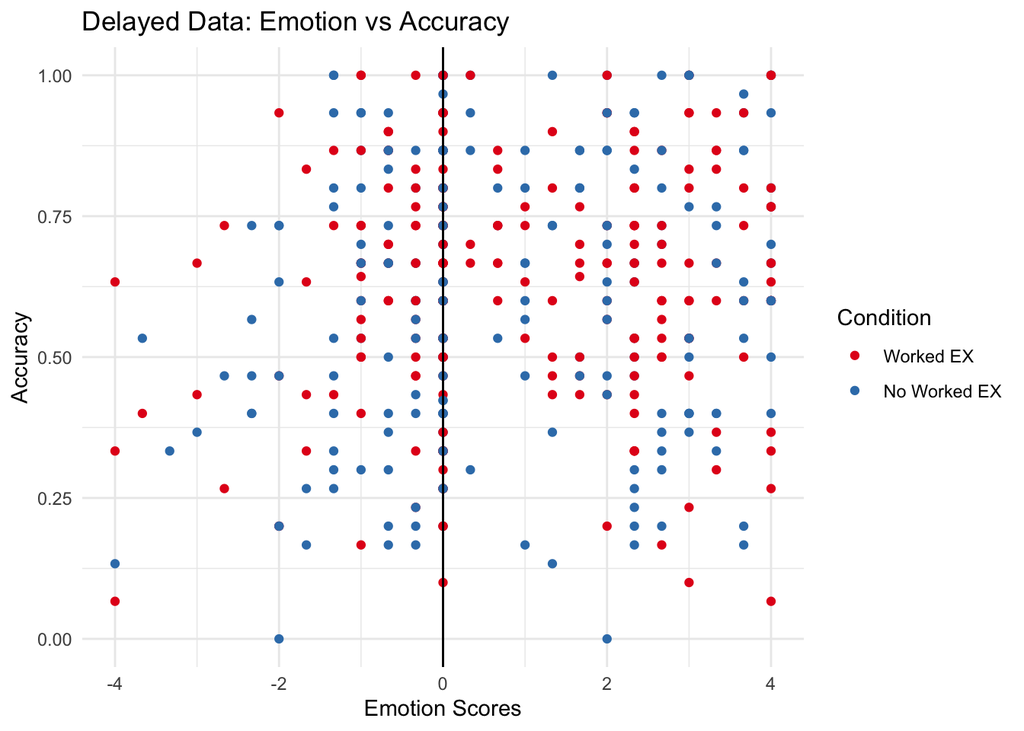

```r
rbind(enjoy, worry2) %>%
  ggplot(aes(x = del, y = del_acc, color = cond)) + geom_point() +
  geom_vline(xintercept = 0) + theme_minimal() +
  labs(title = "Delayed Data: Emotion vs Accuracy", x = "Emotion Scores", y = "Accuracy", color = "Condition") +
  scale_color_brewer(palette="Set1", labels = c("Worked EX", "No Worked EX"))
```

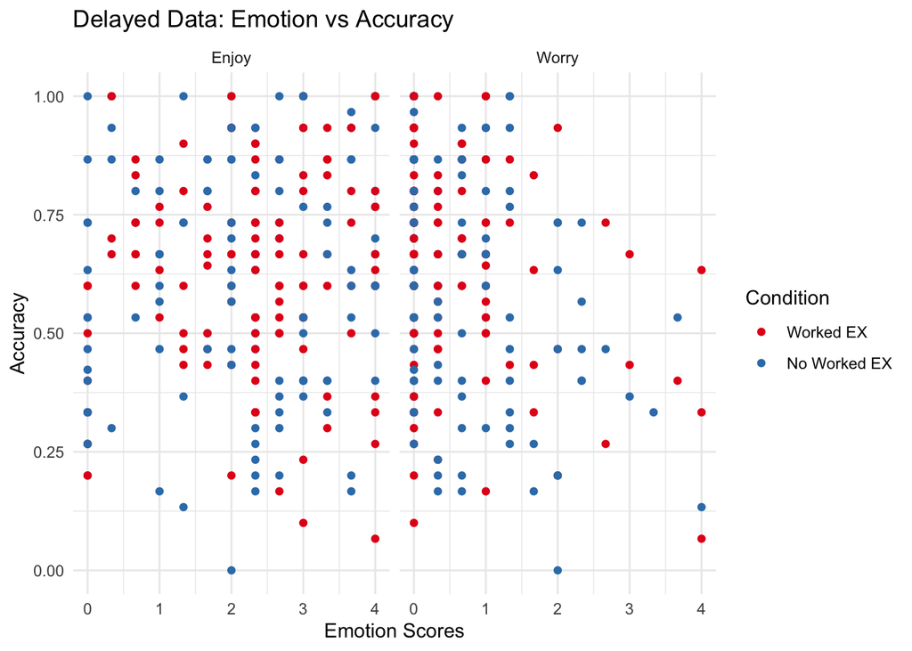

```r
rbind(worry, enjoy) %>%
  ggplot(aes(x = del, y = del_acc, color = cond)) + geom_point() +
  facet_grid(.~emotion, scales = "free", labeller = labeller(enjoy = "Enjoy", worry = "Worry")) +
  theme_minimal() +
  labs(title = "Delayed Data: Emotion vs Accuracy", x = "Emotion Scores", y = "Accuracy", color = "Condition") +
  scale_color_brewer(palette="Set1", labels = c("Worked EX", "No Worked EX"))
```

### Pre-Emotion vs Overall Accuracy

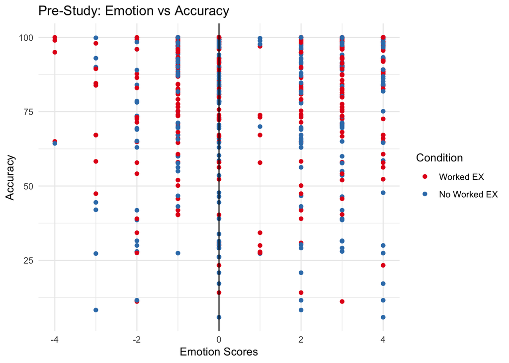

```r
rbind(enjoy, worry2) %>%
  ggplot(aes(x = pre, y = under, color = cond)) + geom_point() +
  geom_vline(xintercept = 0) + theme_minimal() +
  labs(title = "Pre-Study: Emotion vs Accuracy", x = "Emotion Scores", y = "Accuracy", color = "Condition") +
  scale_color_brewer(palette="Set1", labels = c("Worked EX", "No Worked EX"))
```

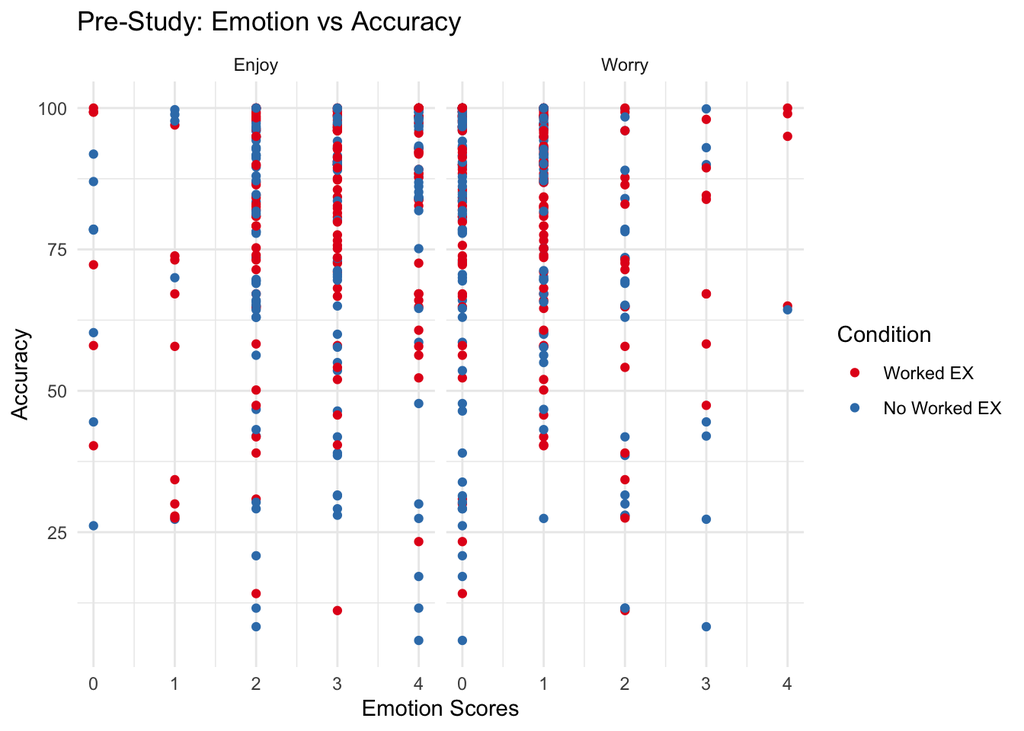

```r
rbind(worry, enjoy) %>%
  ggplot(aes(x = pre, y = under, color = cond)) + geom_point() +
  facet_grid(.~emotion, scales = "free", labeller = labeller(enjoy = "Enjoy", worry = "Worry")) +
  theme_minimal() +
  labs(title = "Pre-Study: Emotion vs Accuracy", x = "Emotion Scores", y = "Accuracy", color = "Condition") +
  scale_color_brewer(palette="Set1", labels = c("Worked EX", "No Worked EX"))
```

## How Does Emotion Change Over Time?

Get the percent change of emotion over three different time periods: during, during immediate, delayed

$$\text{Percent Change} = \frac{\text{Base
Score} - \text{New Score}}{\text{Base Score}}$$

```r
pc_df <-  rbind(enjoy, worry) %>% mutate(
            pc1 = case_when(pre != 0 ~ (pre - dur)/pre,
                             pre == 0 ~ 0),
            pc2 = case_when(pre != 0 ~ (pre - durI)/pre,
                             pre == 0 ~ 0),
            pc3 = case_when(pre != 0 ~ (pre - del)/pre,
                             pre == 0 ~ 0)
            ) %>% select(cond, emotion, contains("pc")) %>%
            group_by(emotion, cond) %>% summarize(pc1_avg = mean(pc1, na.rm = TRUE), pc2_avg = mean(pc2, na.rm = TRUE), pc3_avg = mean(pc3, na.rm = TRUE))
```

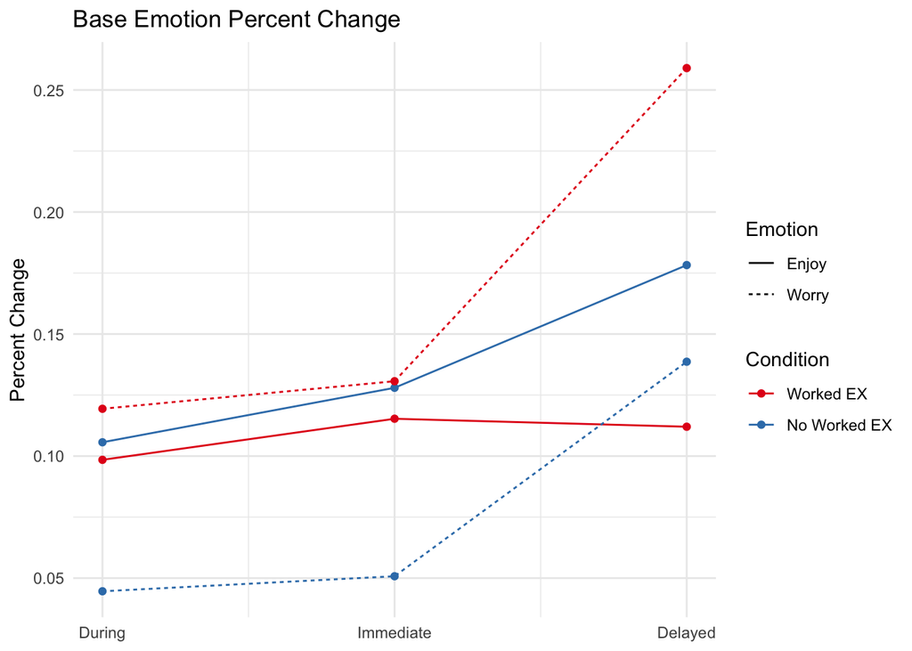

```r
pc1 <- pc_df %>% select(1:3) %>% mutate(period = 1)
pc2 <- pc_df %>% select(1:2,4) %>% mutate(period = 2)
pc3 <- pc_df %>% select(1:2,5) %>% mutate(period = 3)
col_names <-  c("emotion", "cond", "pc", "period")
colnames(pc1) <- col_names
colnames(pc2) <- col_names
colnames(pc3) <- col_names
rbind(pc1,pc2,pc3) %>% ggplot(aes(period,y = pc, color = cond, linetype = emotion)) +
  geom_line() + geom_point() + theme_minimal() +
  labs(title = "Base Emotion Percent Change", y = "Percent Change",
       color = "Condition", linetype = "Emotion") +
  scale_x_continuous(  breaks = c(1, 2, 3),
  label = c("During", "Immediate", "Delayed")) +
  theme(axis.title.x = element_blank()) +
  scale_color_brewer(palette="Set1", labels = c("Worked EX", "No Worked EX"))
```

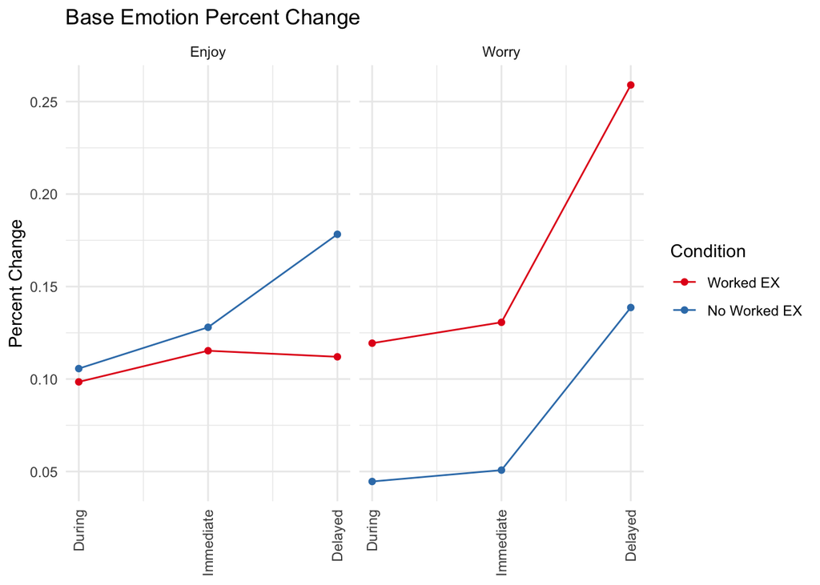

```r
rbind(pc1,pc2,pc3) %>% ggplot(aes(period,y = pc, color = cond)) +
  geom_line() + geom_point() + facet_grid(.~emotion, scales = "free", labeller = labeller(enjoy = "Enjoy", worry = "Worry")) + theme_minimal() +
  labs(title = "Base Emotion Percent Change", y = "Percent Change",
       color = "Condition", linetype = "Emotion") +
  scale_x_continuous(  breaks = c(1, 2, 3),
  label = c("During", "Immediate", "Delayed")) +
  theme(axis.title.x = element_blank(), axis.text.x = element_text(angle = 90, vjust = 0.5, hjust=1)) +
  scale_color_brewer(palette="Set1", labels = c("Worked EX", "No Worked EX"))
```